# Coursework Report

*N* removed NAs: 3

*N* removed typo: 1

*N* removed <18: 18

*N* total clean: 128

| Group | *N* | *M*<sub>age</sub> | *M*<sub>rating</sub> |
| --- | --- | --- | --- |
| Control | 57 | 20.89 | 6.22 |
| Experim | 71 | 20.80 | 5.41 |

**Main analysis results**

*t*(126) = 5.89, *p* < .001

[interactive chart not shown]

[figure not shown]

[interactive chart not shown]

# Coursework Report

Analysing Data, Spring 2020

# Methods

## Participants

For this experiment there was originally 150 participants, due to ethical reasons 3 participants data was removed due to their age not being reported. Therefore, unable to know if they were over 18. Data from 18 other participants had to be removed due them reporting to being under eighteen and 1 participant’s age being non-identifiable. This led data to be analysed from 128 participants aged 18 to 25( M age=20.84,SD age = 1.76).

## Design

This experiment was a replication of the Elliot et al (2010) study investigating if the colour red enhances how attractive she perceives a man and if it increases the perception she has on the male’s status. To measure the attractiveness of the male a rating from 1 (not at all attractive) to 9 (extremely attractive). For this participants had to answer three questions “How attractive do you think this person is?”, “How pleasant is this person to look at?” and “If I were to meet the person in this picture face to face, I would think he is attractive.” using the 1-9 scale rating. The higher the rating of attractivness on a scale 1-97 the more attractive they would find the individual. There is a difference in the attractiveness of a male when a picture of him is placed on a red or white background and is rated by females on a scale of 1-9. The statistical test used is the t-test for this experiment.

# Results

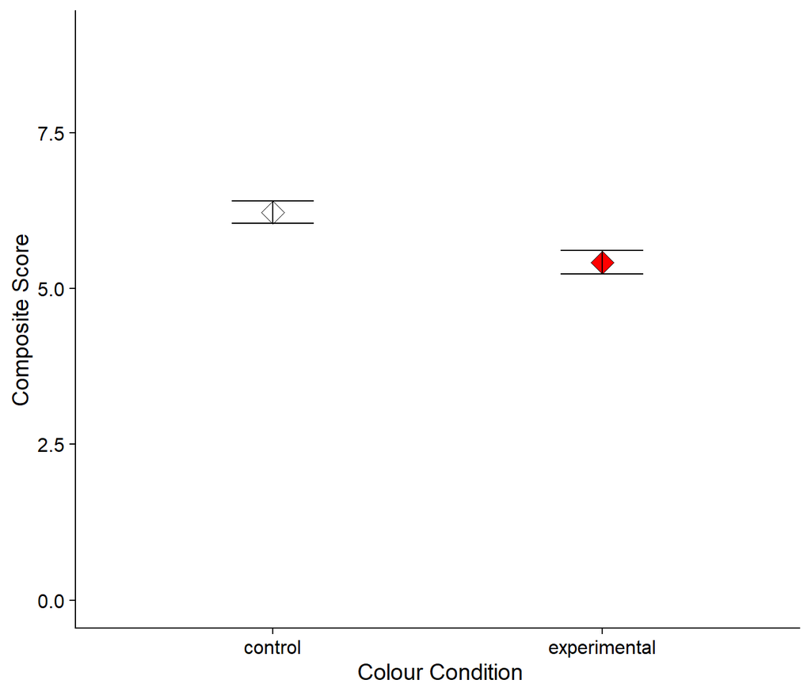

Figure 1: Compostion Score of Control and Experiment Condition

For our experiment looking to see if different coloured backgrounds affect attractivieness rating of a male we used an independent-measures *t*-test. The control group showed a mean of (*M* = 6.22) where as the experimental group (*M* = 5.41). The difference is significant (*M*<sub>diff</sub> = 0.8, 95% CI [0.53, 1.07], *t* (126) = 5.89, *p* = <.001) suggesting that the colour did affect perceived attractiveness ratings, in this case white showing the opposite to Elliot (2010) and that the method may not be replicable due to different results.Therefore, we can reject the null hypothesis.

# Discussion

The experiment shows that the control group (white backgroud) produced a higher mean score then the red experiment group which indicates the opposite effect to the Elliot (2010) that suggested that red background would cause a higher rating of attractiveness. This suggest that there may be confounding variables or limitations in one or both of these experimemnts to why there is a difference in results. Francis, (2013) reviewed the Elliot (2010) paper and concluded that there was publication bias as it is suggested that some of the experiments where there were null findings were not reported. Those experiments that were reported are suggested to have been conducted incorrectly so that it meant that the null hypothesis was more likely rejected. Therefore, this may give some indication as to why there is a difference between results from the current experiment and Elliot (2010).

As a result of Francis (2013) criticism, Elliot & Maier (2013) conducted the experiment again regarding women’s rating of men’s attractiveness but with a larger sample compared to the original study. The results showed that women still found mean more attractive with a red background (M= 6.53) compared to a grey background (M=5.93). However, the statistical significance between them was not enough, so they declared that the study was “inconclusive regarding the red-attractiveness”. This suggest that there needs to be more work done in this area and that maybe other variables need to be considered e.g. does a woman find a male more attractive if his t-shirt is red or is there a specific hue of red that causes a male to be more attractive. To add to this Lehmann & Calin-Jageman (2017) replicated the Elliot (2010) and Elliot & Niesta (2008) using both online and in person samples to ensure that there was more generalisability. From their online and in-person it showed that there was no significant effects for colour when measuring perceived attraction, However, they did find a weak red effect if the red photo was shown first (M=5.77) grey= (M=5.33) but there was no effect if presented second. This could indicate that seeing someone in red first can cause them to be more attractive. However, the findings are not very strong.

Robert et al,.(2010) found that if a male was wearing either a red or black t-shirt the female rated their attractiveness higher then when they wore colours such as white or blue. This indicated that it may not just be one colour that perceives a male to be more attractive and that wearing the item of clothing, compared to the colour being part of the background may be a reason why previous and this experiment do not share similar results. To improve the ecological validity of experiments such as Elliot (2010) and replications, the male should be wearing a coloured t-shirt as it’s not often that you view an individual on a solid colour background. For future research, research could be done on if women find men in different colours t-shirt more attractive and look into their biologyof the brain, as there may something within our brains that may cause some wowen to find men in black more attractive. Whereas, something else causing other women to find men in another colour more attractive.

Hesslinger et al., (2015) also replicated Elliot (2010) first experiment and found there was no significant impact that red background caused more attractiveness. They also looked at weather the style of clothing worn by the male e.g. formal or casual on a red or white background would cause a women to perceive an individual as more attractive. Findings were that there was a significant effect of peceived attractiveness if the male was wearing formal clothing compared to casual and the red background had no effect. Suggesting that the style of clothing the male wears in the photo will impact on his attractiveness, so this variable needs to be considered and looked more into.

Other limitations of Elliot, (2010) first experiment and this current replication is that there was only one male that participants would rate. Therefore, does not give a large indication on if the red effects happens to all men or if the red effect only occurs to men of a certian level of attractiveness or certian face structure. To add to this Penton-voak & perrott, (2000) found that women were more likely to choose a masculine male face in their follicular phase of their menstural cycle then when in their menses and luteal phrases Suggesting that studies looking into attractiveness rating also need to consider the masculinity of the males face and menstrual cycle of the female. For some support of red causing males to be perceived as more attractive Stephen & Mckeegan (2010) found that females would slightly increase the redness on a male’s face to make him more attractive but reduced redness to make the face more masculine. Therefore, there could be a possibility that red on a male’s face help with him being seen more attractive.

Strengths of this study include that there was a large sample of participants meaning that the results are more generalisable. As well as this, the experiment is easily replicated (Hasslinger et al,.2015), meaning that finding more participants to do the experiment is easy and that there is not a lot of expense that goes into producing the experiment. Also, the task that participants have to complete is not a challenge task, although this may make it easier to guess what the study is about. From this study and others it shows that there is mixed evidence on whether red or other colours affect attractiveness ratings but there is indications that some colours e.g. red or black have an effect compared to green and yellow do not (Robert et al.,2010).

Overall, it seems that there is not enough evidence that red makes a female perceive a male as more attractive, but can be tried, as there is some evidence to support. However this study did not show that red caused higher perceived attraction ratings. For future research, more needs to be looked into a male actually wearing the colour t-shirt to increase ecological validity and that women should be showed more than one picture of a male within the experiment to see if the red effect just occurs for certain males and that these males may need to wear different types of clothing to see when the red effect does occur.

# References

Elliot, A. J., & Maier, M. A. (2013). The red-attractiveness effect, applying the Ioannidis and Trikalinos (2007b) test, and the broader scientific context: A reply to Francis (2013). Journal of Experimental Psychology: General, 142(1), 297–300. http://dx.doi.org/10.1037/a0029592

Elliot, A. J., Niesta Kayser, D., Greitemeyer, T., Lichtenfeld, S., Gramzow, R. H., Maier, M. A., & Liu, H. (2010). Red, rank, and romance in women viewing men. Journal of Experimental Psychology: General, 139(3), 399–417. https://doi.org/10.1037/a0019689

Francis, G. (2013). Publication bias in “Red, rank, and romance in women viewing men,” by Elliot et al. (2010). Journal of Experimental Psychology: General, 142(1), 292–296. http://dx.doi.org/10.1037/a0027923

Hesslinger, V. M., Goldbach, L., & Carbon, C.-C. (2015). Men in red: A reexamination of the red-attractiveness effect. Psychonomic Bulletin & Review, 22(4), 1142–1148. https://doi.org/10.3758/s13423-015-0866-8

Lehmann, G. K., & Calin-Jageman, R. J. (2017). Is Red Really Romantic? Social Psychology. https://econtent.hogrefe.com/doi/abs/10.1027/1864-9335/a000296

Penton-Voak, I. S., & Perrett, D. I. (2000). Female preference for male faces changes cyclically: Further evidence. Evolution and Human Behavior, 21(1), 39–48. https://doi.org/10.1016/S1090-5138(99)00033-1

Roberts, S. C., Owen, R. C., & Havlicek, J. (2010). Distinguishing between Perceiver and Wearer Effects in Clothing Color-Associated Attributions: Evolutionary Psychology. https://doi.org/10.1177/147470491000800304

Stephen, I., & McKeegan, A. (2010). Lip color affects perceived sex typicality and attractiveness. Perception, 39, 1104–1110. https://doi.org/10.1068/p6730